# Third Assignment

Christopher Gandrud, Hertie School of Governance, Spring 2016

Emilia Sicari & Rafael Lopez V.

March 25, 2016

# Research question and project description

In our collaborative research project, we seeks to provide an answer to the following question: **How the rise in inequality and economic growth influences the purchase of cars as an example of luxury goods, compared to the usage of public transportation systems in Singapore, from 1995 to 2014**.

Therefore, we collected data on economic growth, income inequality, usage of public transports and purchase of cars covering the time span of 19 years, from 1995 until 2014. As suggested by our research question, economic growth and income inequality are the explanatory variables, while purchase of cars and usage of public transports are the dependent variables. The reason why we chose cars as example of luxury goods showing social status, is that in Singapore purchasing of cars is particularly expensive, due to high taxation and the need to own a certificate of car entitlement, whose cost can be higher than 70.000 dollars. For more details about the research proposal and case justification see ResearchProposal.

# Processing data

## Data sources and data gathering

The data for our empirical analysis were retrieved from:

- IMF Cross Country Macroeconomic Statistics open data available on [Quandl](https://www.quandl.com/data/ODA/SGP_NGDPPC). From this source we downloaded data showing the trend in Singopore’s GDP per capita meassured in singaporean dollars from 1995 to 2014. The data was provided in csv format and imported on R using the URL of the website.
- World Top Incomes Database available on [Knoema](http://knoema.com/), providing access to data on the distribution of top incomes in more than twenty five countries across the globe. From this source we downloaded data on the top 10% average income and bottom 90% average income in Singapore from 1947 until 2009, meassured in singaporean dollars. Since it was not possible to directly import the database to R, we requested and received the data via e-mail in csv format. Such data are available in the repository.  
  The reason why we did not gather data from the database [Clio Infra](https://www.quandl.com/data/CLIO/SGP_II-Income-Inequality-Singapore) available on Quandl as we had defined in our ResearchProposal , is that it did not provide sufficient data for the time span we are considering.
- [Singapore’s open data portal](https://data.gov.sg) offered two databases:
  - The [Annual Motor Vehicle Population](https://data.gov.sg/dataset/annual-motor-vehicle-population-by-type-of-vehicles), providing provides the number of public and private vehicles from 1995 to 2014, including: mortorbikes, rental cars, buses, taxis and other type of vehicles. While mortorbikes, rental cars and cars are private means of transportation, buses and taxis are to be considered public since in Singapore even the taxis are provided by the state.
  - [Public transport utilization](https://data.gov.sg/dataset/public-transport-utilisation-average-public-transport-ridership). This data is expressed as the daily average of thounsand commuters using public trasport by year. It covers the span from 1995 to 2014 and includes the following modes of transportation: MRT (underground), LRT (a localised rail systems acting as feeder services to the Mass Rapid Transit network), taxis (publicly run) and buses.

The following table summarizes the variables taken into consideration for the analysis.

Variable

Description

Time.frame

```
   gdp per capita
```

measured in singaporean dollars at current prices. From 1995 to 2014

1980-2014

```
     inequality
```

```
top 10% and bottom 90%
```

singaporean’s average income measured in singaporean dollars

1947-2009

```
anual motor vehicle
```

number of: cars, rental cars, buses, taxis, buses, motorbikes

1960-2015

public transport utilization

average commuters using daily: MRT, LRT, Buses, Taxis

1995-2014

## Cleaning, processing and merging of datasets

- After importing data we used the “date” variable (year) as a unique identifier for all four datasets, in order to merge them afterwards.
- Since time frames of the data were different, we selected a common span of time: 1995-2014. In the case of bottom 90% and top 10% average income, we had to make a linear regression to forecast missing values (from 2009 until 2014). The results, available in a new dataframe, were later on bounded with the orginal one, in order to have the entire time series. As for LRT, values from 1995 until 1998 were missing since the service started to be provided from 1999; therefore, we completed the dataframe giving the value “0” for the first 4 years of the time span taken into consideration.
- Cleaning the data was limited to changing column names, eliminating the unnecesary ones and organizing the various data frames so to merge them more easily afterwards, using the year as common denominator. Only in the case of the dataframe cointaining the number of private cars in Singapore from 1995 until 2014 (car.pop.1) we had to change the format of the data from characters to integers, due to an incorrect import.
- In order to have an indicator showing the trend in inequality in Singapore between 1995 and 2014, we created a new variable - named “inequality” - by divididing the top 10% avereage income by the bottom 90% average income for each year: the coefficient of the division shows how many times Singaporeans earning the top 10% average income are reacher than the bottom 90% earners of the population.
- As for the number of cars, we simply divided them into the categories provided in the data original set: cars, buses, etc. Originally, they were in one column so we separate them in several ones to have the year as a unique identifier.
- Finally, we merged all the single dataframes into the new one, containing all the variables that we used to perfom descriptive and inferential statistical analyses.  
  #Descriptive and inferential statistics

## Trends in gdp per capita and inequality

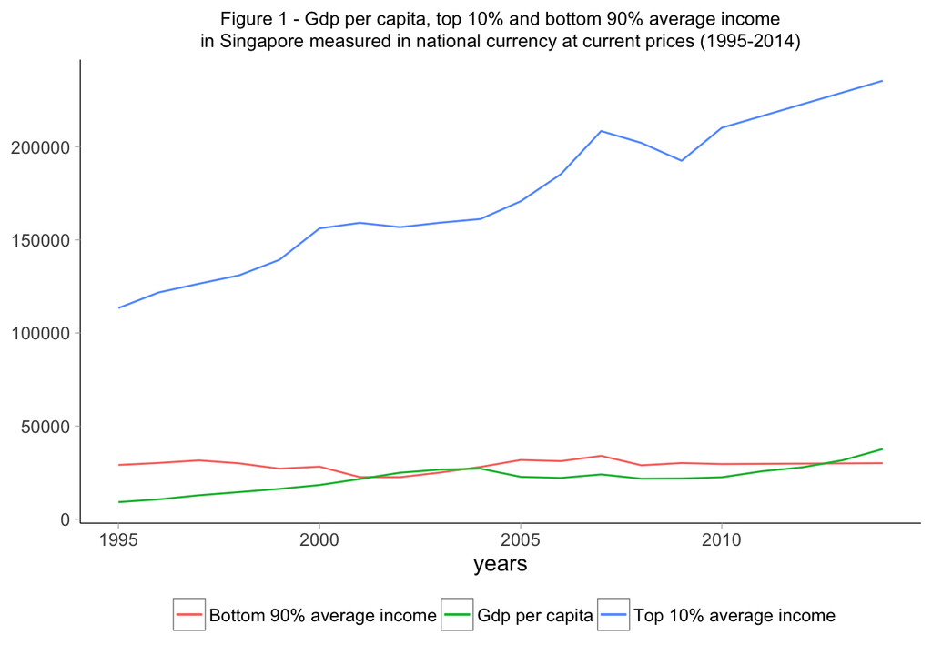

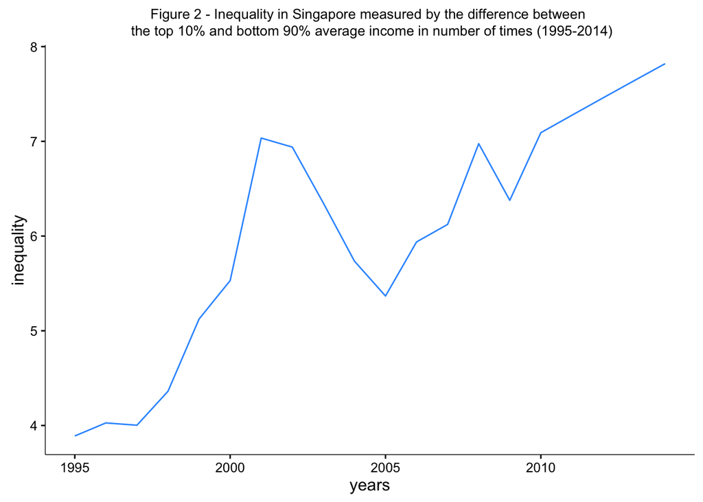

## Trends in ownership and usage of vehicles

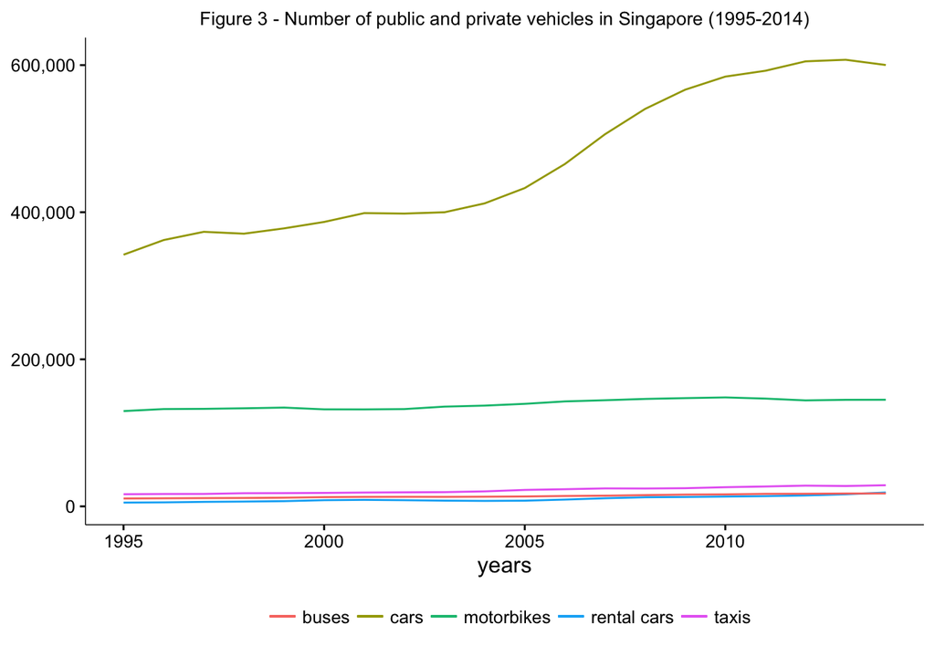

[figure not shown]

# Coorelation analysis

A first step to check out our new assumptions is to see the correlation between the variables included in the model, shown by the plot below: blue indicates negative correlation between variables, while red highlights positive correlations; color intensity and the size of the circles are proportional to the correlation coefficients, and the correlation coefficients corresponding to the color intensity are shown in the legend below the diagram. What clearly emerges from the plot, is that the variables are in almost all of the cases highly and positively correlated to each other. Bottom 90% average income and buse utilization are less correlated to the other variables, and bottom 90% average income is also negatively correlated with both inequality and buses utilization (which weakens the assumption that the poorest are those who use more public transportations). However, high correlation among explanatory variables might create problems in multiple regression analysis (multicollinearity). Therefore, it is necessary to explore collinearity before proceeding to the regression analysis.

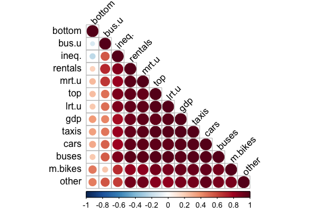

|  | gdp | ineq. | cars | rentals | taxis | buses | m.bikes | other | bus.u | mrt.u | top | bottom | lrt.u |
| --- | --- | --- | --- | --- | --- | --- | --- | --- | --- | --- | --- | --- | --- |
| gdp | 1.00 | 0.87 | 0.71 | 0.80 | 0.78 | 0.81 | 0.62 | 0.53 | 0.46 | 0.80 | 0.83 | -0.07 | 0.86 |
| ineq. | 0.87 | 1.00 | 0.80 | 0.86 | 0.81 | 0.88 | 0.68 | 0.63 | 0.55 | 0.81 | 0.88 | -0.23 | 0.88 |
| cars | 0.71 | 0.80 | 1.00 | 0.95 | 0.98 | 0.98 | 0.94 | 0.95 | 0.52 | 0.96 | 0.96 | 0.32 | 0.95 |
| rentals | 0.80 | 0.86 | 0.95 | 1.00 | 0.94 | 0.97 | 0.83 | 0.90 | 0.69 | 0.97 | 0.95 | 0.19 | 0.95 |
| taxis | 0.78 | 0.81 | 0.98 | 0.94 | 1.00 | 0.98 | 0.93 | 0.90 | 0.47 | 0.97 | 0.98 | 0.35 | 0.98 |
| buses | 0.81 | 0.88 | 0.98 | 0.97 | 0.98 | 1.00 | 0.90 | 0.89 | 0.54 | 0.97 | 0.98 | 0.22 | 0.98 |
| m.bikes | 0.62 | 0.68 | 0.94 | 0.83 | 0.93 | 0.90 | 1.00 | 0.89 | 0.23 | 0.84 | 0.90 | 0.46 | 0.89 |
| other | 0.53 | 0.63 | 0.95 | 0.90 | 0.90 | 0.89 | 0.89 | 1.00 | 0.56 | 0.91 | 0.85 | 0.45 | 0.83 |
| bus.u | 0.46 | 0.55 | 0.52 | 0.69 | 0.47 | 0.54 | 0.23 | 0.56 | 1.00 | 0.65 | 0.48 | -0.14 | 0.49 |
| mrt.u | 0.80 | 0.81 | 0.96 | 0.97 | 0.97 | 0.97 | 0.84 | 0.91 | 0.65 | 1.00 | 0.94 | 0.27 | 0.96 |
| top | 0.83 | 0.88 | 0.96 | 0.95 | 0.98 | 0.98 | 0.90 | 0.85 | 0.48 | 0.94 | 1.00 | 0.26 | 0.98 |
| bottom | -0.07 | -0.23 | 0.32 | 0.19 | 0.35 | 0.22 | 0.46 | 0.45 | -0.14 | 0.27 | 0.26 | 1.00 | 0.22 |
| lrt.u | 0.86 | 0.88 | 0.95 | 0.95 | 0.98 | 0.98 | 0.89 | 0.83 | 0.49 | 0.96 | 0.98 | 0.22 | 1.00 |

## Multiple regression analysis

[output not shown]

## Further steps

- investigating collinearity